# Wines Exploration by José Gildo

This work aims to compare red and white wines datasets. Both datasets are available on the dataset options [here](https://docs.google.com/document/d/e/2PACX-1vRmVtjQrgEPfE3VoiOrdeZ7vLPO_p3KRdb_o-z6E_YJ65tDOiXkwsDpLFKI3lUxbD6UlYtQHXvwiZKx/pub?embedded=true) for this project.

There main question that we will try to answer is:

- Which are the chemical properties has the biggest relationship with quality?

This report explores a dataset of red and white wines about many perspectives. Red wines dataset has information about 1,599 wines. White wines dataset has information about 4,898 wines. Both databases have 6,497 lines and 13 variables.

# Univariate Plots Section

**Red Wines:**

```
##        X          fixed.acidity   volatile.acidity  citric.acid
##  Min.   :   1.0   Min.   : 4.60   Min.   :0.1200   Min.   :0.000
##  1st Qu.: 400.5   1st Qu.: 7.10   1st Qu.:0.3900   1st Qu.:0.090
##  Median : 800.0   Median : 7.90   Median :0.5200   Median :0.260
##  Mean   : 800.0   Mean   : 8.32   Mean   :0.5278   Mean   :0.271
##  3rd Qu.:1199.5   3rd Qu.: 9.20   3rd Qu.:0.6400   3rd Qu.:0.420
##  Max.   :1599.0   Max.   :15.90   Max.   :1.5800   Max.   :1.000
##  residual.sugar     chlorides       free.sulfur.dioxide total.sulfur.dioxide
##  Min.   : 0.900   Min.   :0.01200   Min.   : 1.00       Min.   :  6.00
##  1st Qu.: 1.900   1st Qu.:0.07000   1st Qu.: 7.00       1st Qu.: 22.00
##  Median : 2.200   Median :0.07900   Median :14.00       Median : 38.00
##  Mean   : 2.539   Mean   :0.08747   Mean   :15.87       Mean   : 46.47
##  3rd Qu.: 2.600   3rd Qu.:0.09000   3rd Qu.:21.00       3rd Qu.: 62.00
##  Max.   :15.500   Max.   :0.61100   Max.   :72.00       Max.   :289.00
##     density             pH          sulphates         alcohol
##  Min.   :0.9901   Min.   :2.740   Min.   :0.3300   Min.   : 8.40
##  1st Qu.:0.9956   1st Qu.:3.210   1st Qu.:0.5500   1st Qu.: 9.50
##  Median :0.9968   Median :3.310   Median :0.6200   Median :10.20
##  Mean   :0.9967   Mean   :3.311   Mean   :0.6581   Mean   :10.42
##  3rd Qu.:0.9978   3rd Qu.:3.400   3rd Qu.:0.7300   3rd Qu.:11.10
##  Max.   :1.0037   Max.   :4.010   Max.   :2.0000   Max.   :14.90
##     quality
##  Min.   :3.000
##  1st Qu.:5.000
##  Median :6.000
##  Mean   :5.636
##  3rd Qu.:6.000
##  Max.   :8.000
```

**White Wines:**

[output not shown]

**Compare both classes of wine for each attributes:**

**Histogram over all variables on the database:**

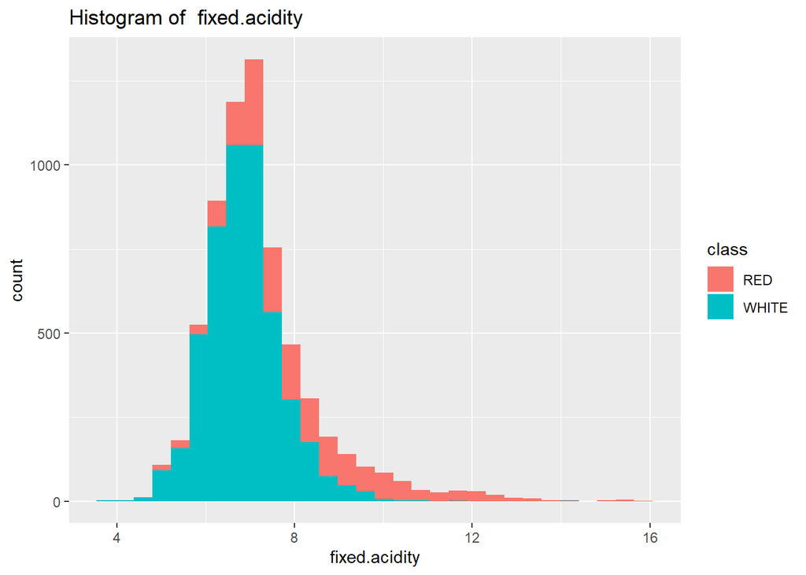

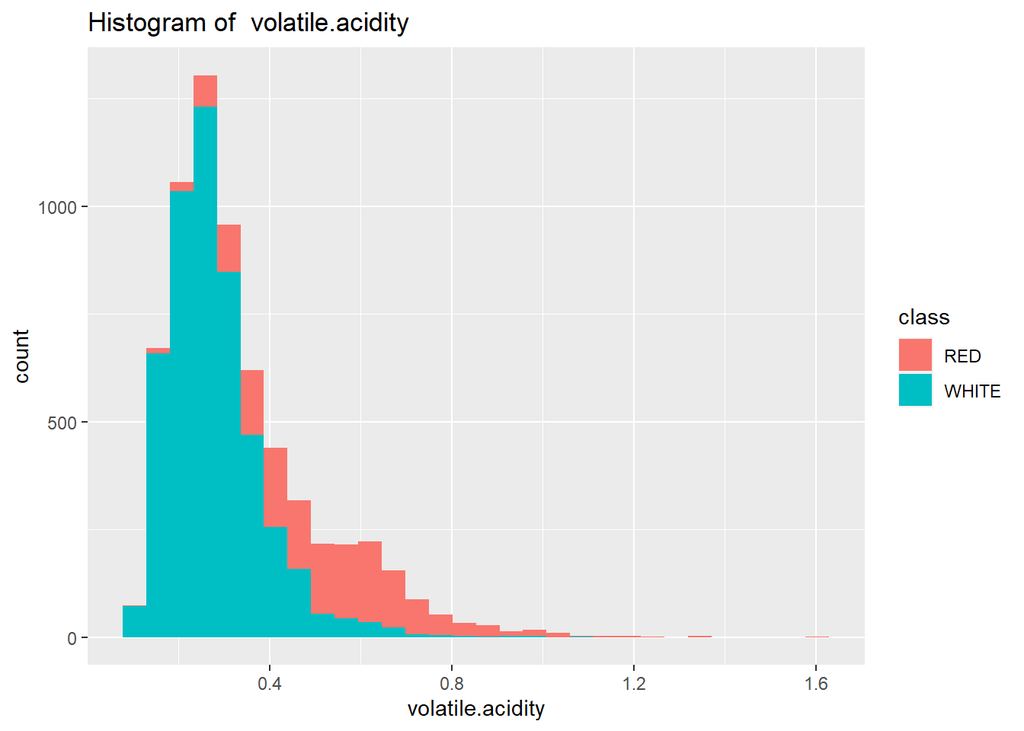

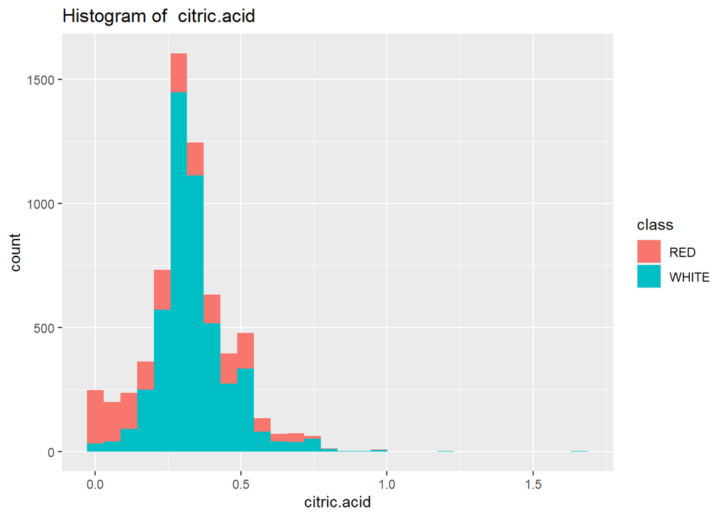

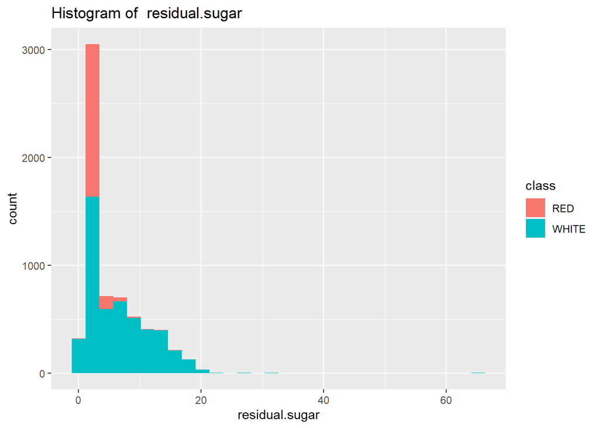

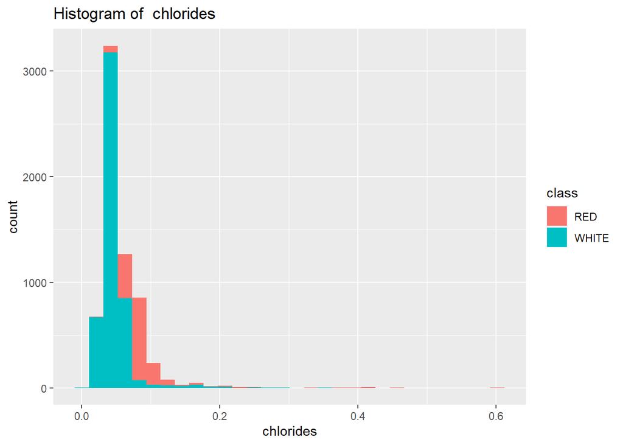

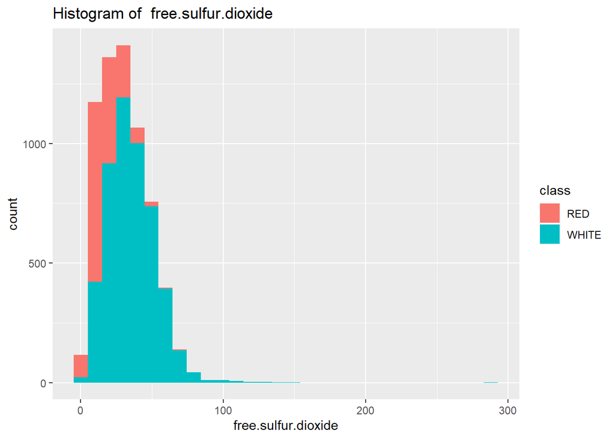

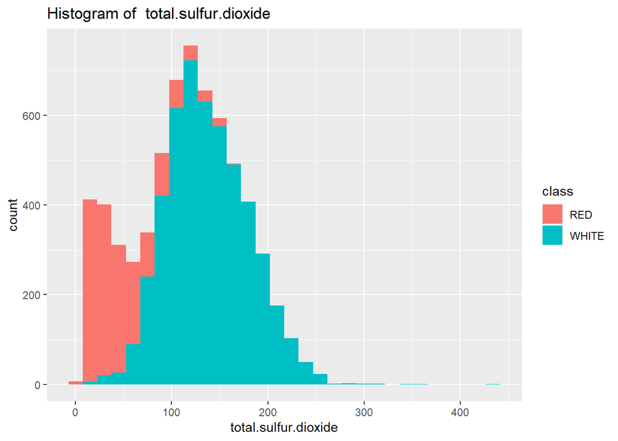

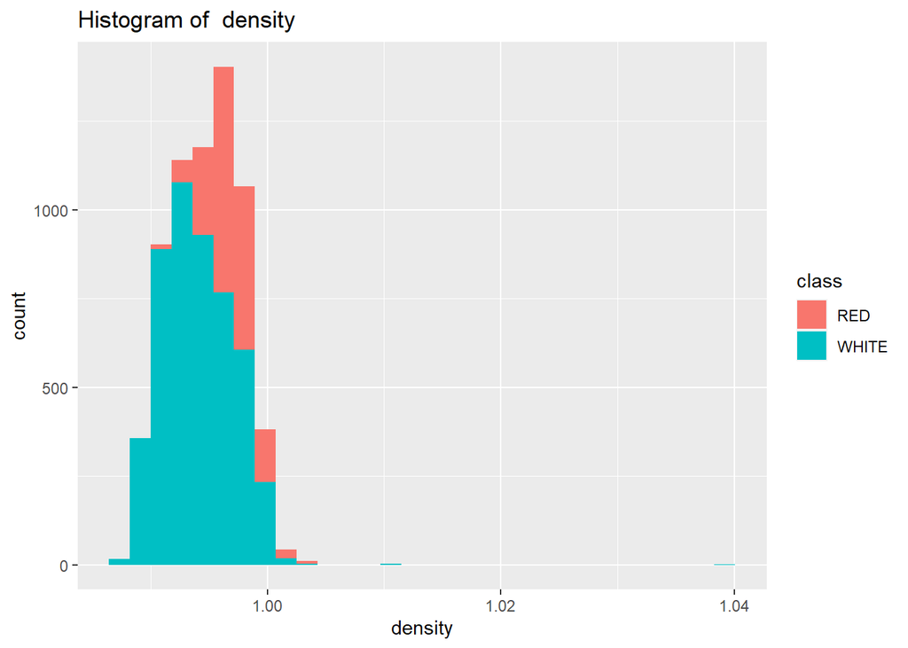

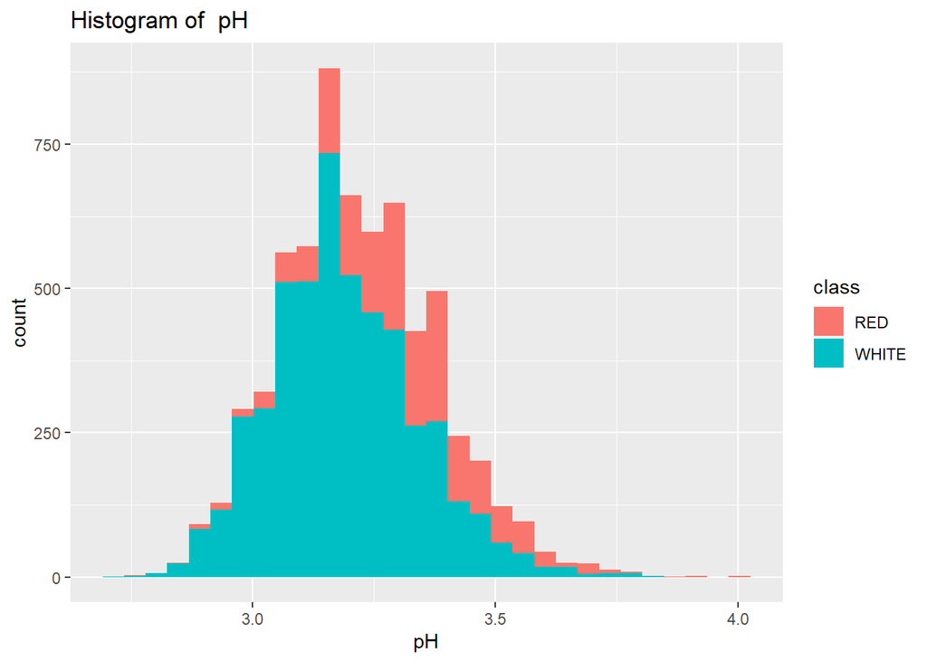

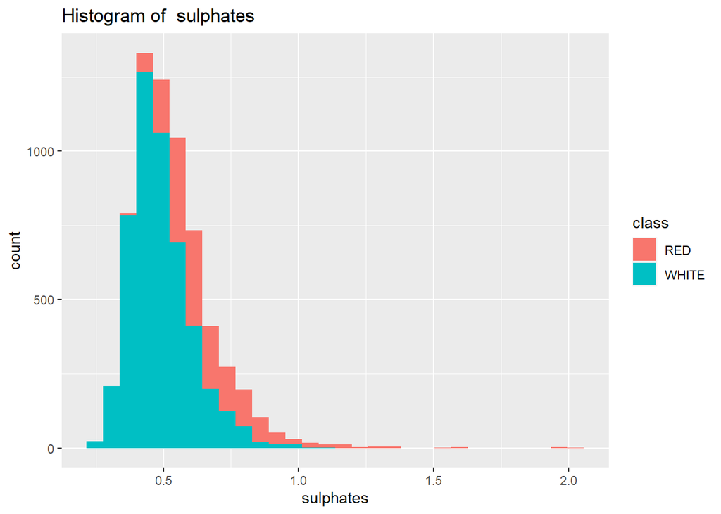

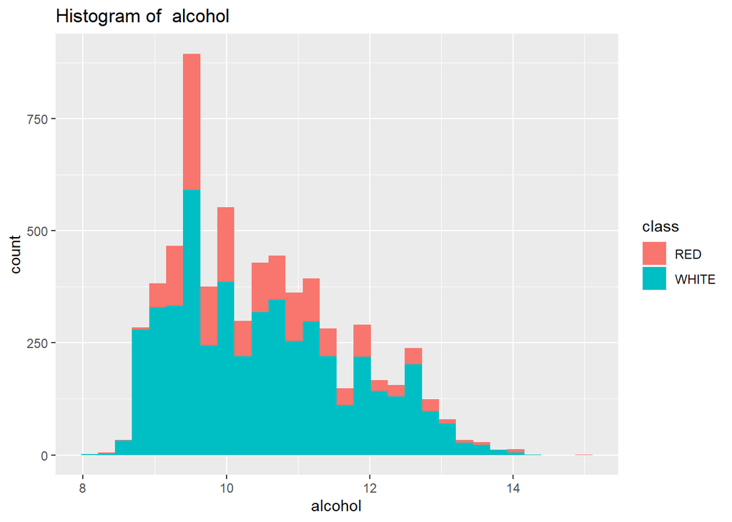

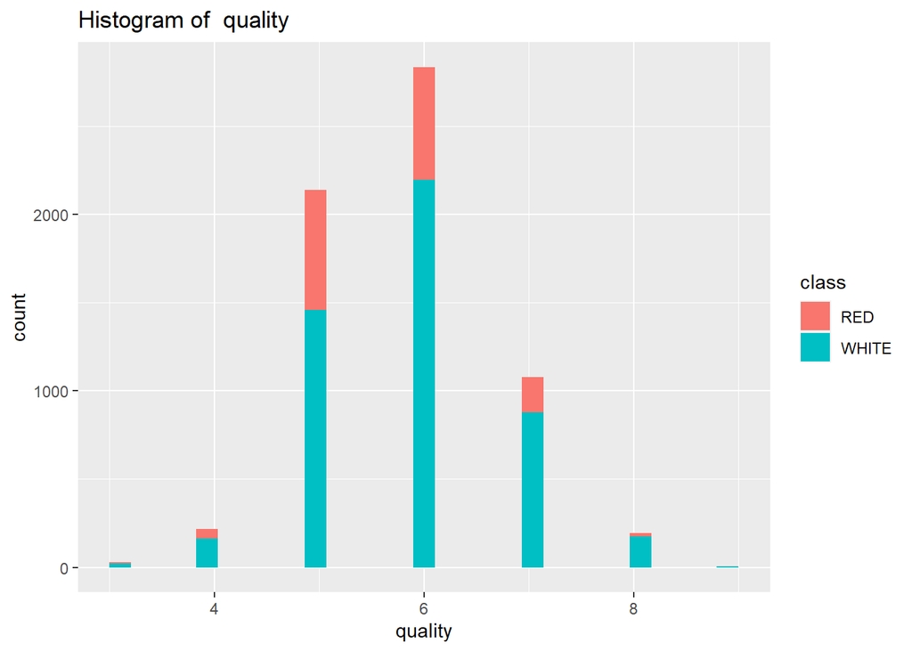

**Red and White wines over all attributes in median values:**

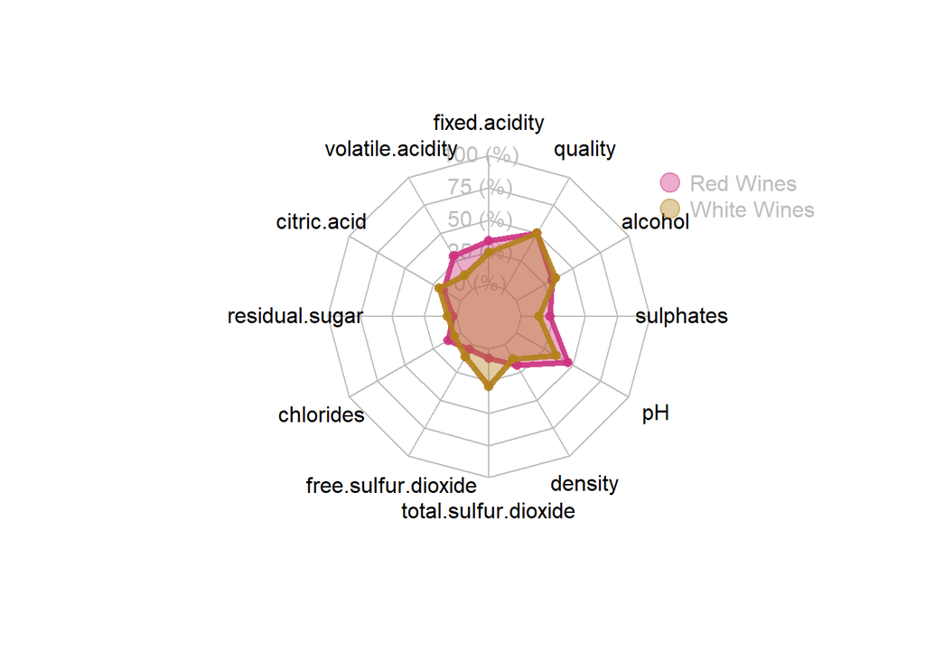

**Best and Worse Red Wines comparation:**

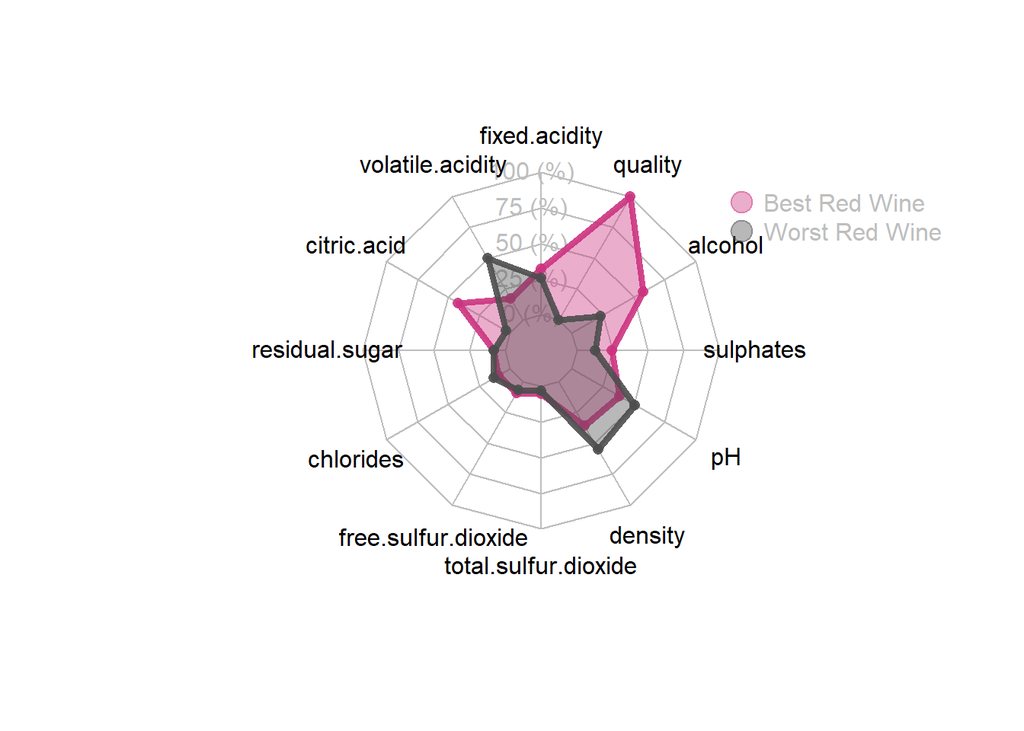

**Best and Worse White Wines comparation:**

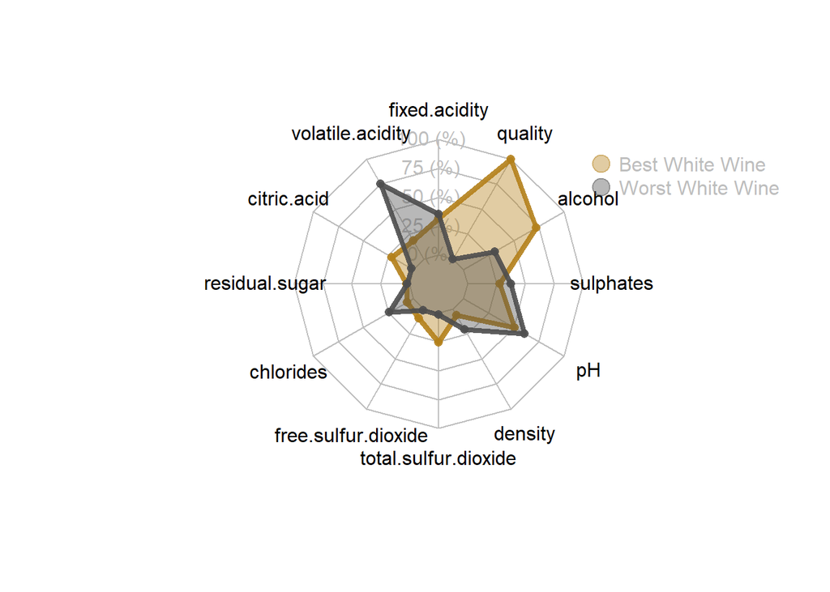

# Univariate Analysis

### What is the structure of your dataset?

Red wines dataset has information about 1599 wines. White wines dataset has information about 4898 wines. Both databases have 6,497 lines and 13 variables.

### What is/are the main feature(s) of interest in your dataset?

The main feature in the data set is **quality**. We would like to determine which are best and minimal combination of features for determine the quality of a wine.

### What other features in the dataset do you think will help support your investigation into your feature(s) of interest?

Others features that will help our analysis for both wines: *age of wines*, *kind of grapes*, *price of the botter*, *region of wine*, *is a blend or not*. For Red Wines we have visible differences when we compare hight and low quality wines. It is possible notice that *alcohol*, *citric.acid* and *volatile.acidity* are (apparently) inversely proportional. However, white wines have a remarkable difference in *alcohol* attribute and subtle differences in *pH* and *density*.

### Did you create any new variables from existing variables in the dataset?

No. I created a new dataset joining red and white wines datasets.

### Of the features you investigated, were there any unusual distributions?

It was necessary to adjust the dataset to make them tailored to use libraries to build the presented graphs.

**Some observations:**

**Acidity:**

- **Citric Acid:** In general, white wines are more citric than red wines and it is natural due to the grapes used in the process;
- **Volatile Acidity:** In geral, red wines have more volatile acidity than white wines;
- **Fixed Acidity:** In general, red wines have more fixed acidity than white wines;
- **Chlorides:** In general, red wines have more chlorides than white wines probably relate to the physical-chemical production process. For both wines are many variability about this attribute;
- **Density:** In general, red wines have more density than white wines. Density is an important factor to harmonize with fat because of that it is common to serve red wine with fatty meats. This is an expected result. White wines are refreshing and much density is not interesting for this propouse;

**- Sulphates:** In general, red wines have more sulphates than white wines, but for both wines are a low variability for this variable.

**Sulfur:**

**- Total and Free Sulfur Dioxide:** Based in Sulfur Dioxide is used to prevent oxidation and microbial growth. However, an excessive amounts of SO2 can inhibit fermentation and cause undesirable sensory effects.

**- Residual Sugar:** In general, red wines have next to nothing residual sugar. White wines have more variability and more residual sugar than red wines. The distribution of this variability seems to be skewed;

**- Quality:** Even with different combinations of attributes, both wines arrives similar quality.

# Bivariate Plots Section

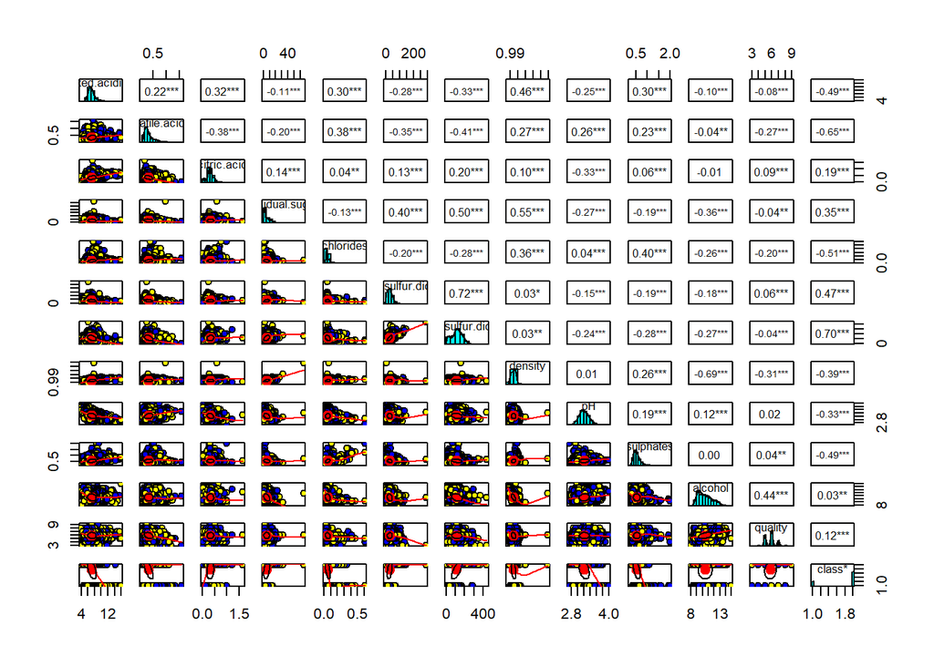

There are many interesting things this graph shows to us:

- The variables most related with *quality* are: alcohol, density and volatile acid. Indeed, everyone who drinks wine knows that these three variables sum up the main properties of a wine. This observation shows consistency between the data and common sense;
- These considerations are considering all wines (white and red).

**All Wines:**

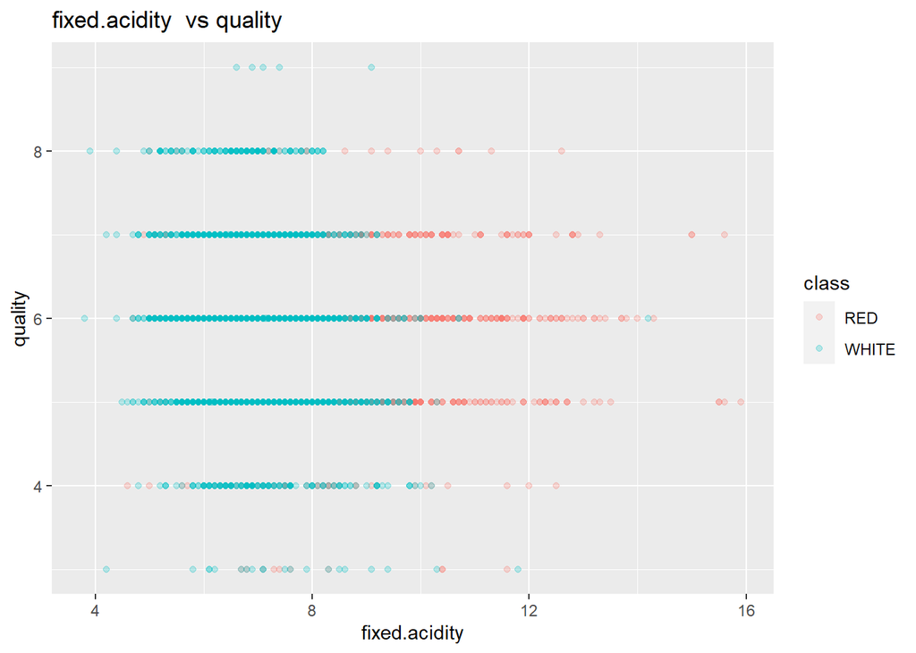

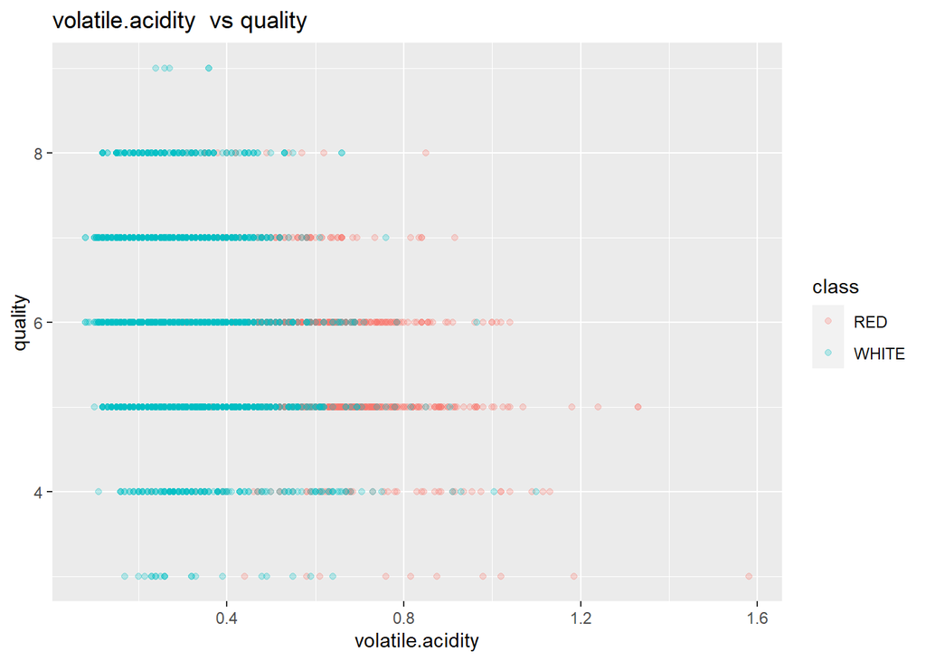

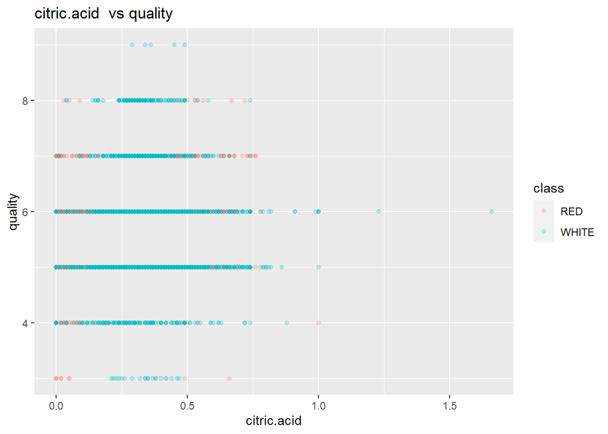

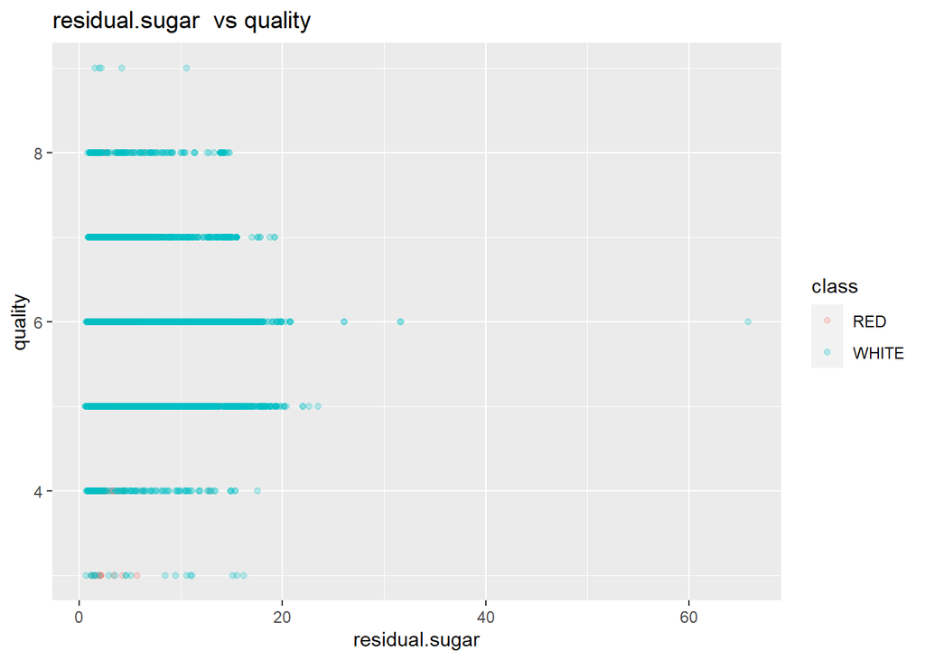

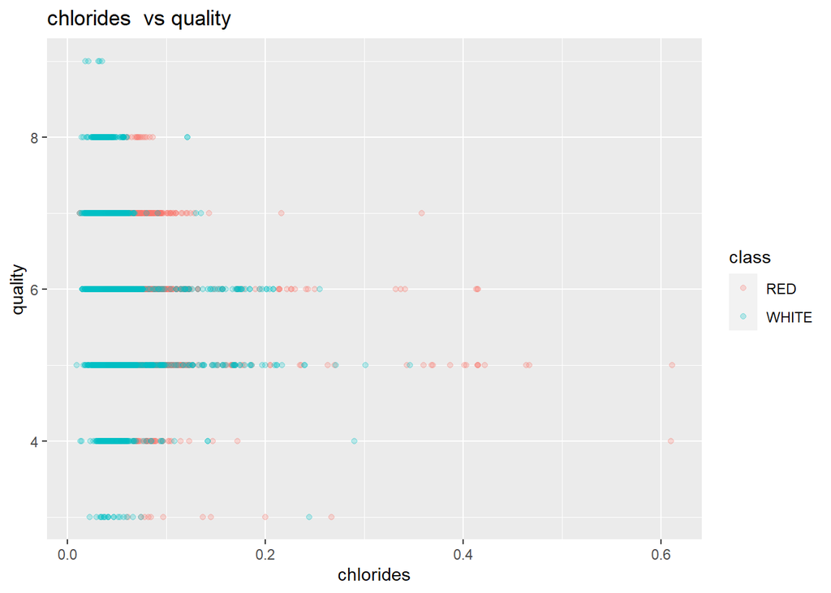

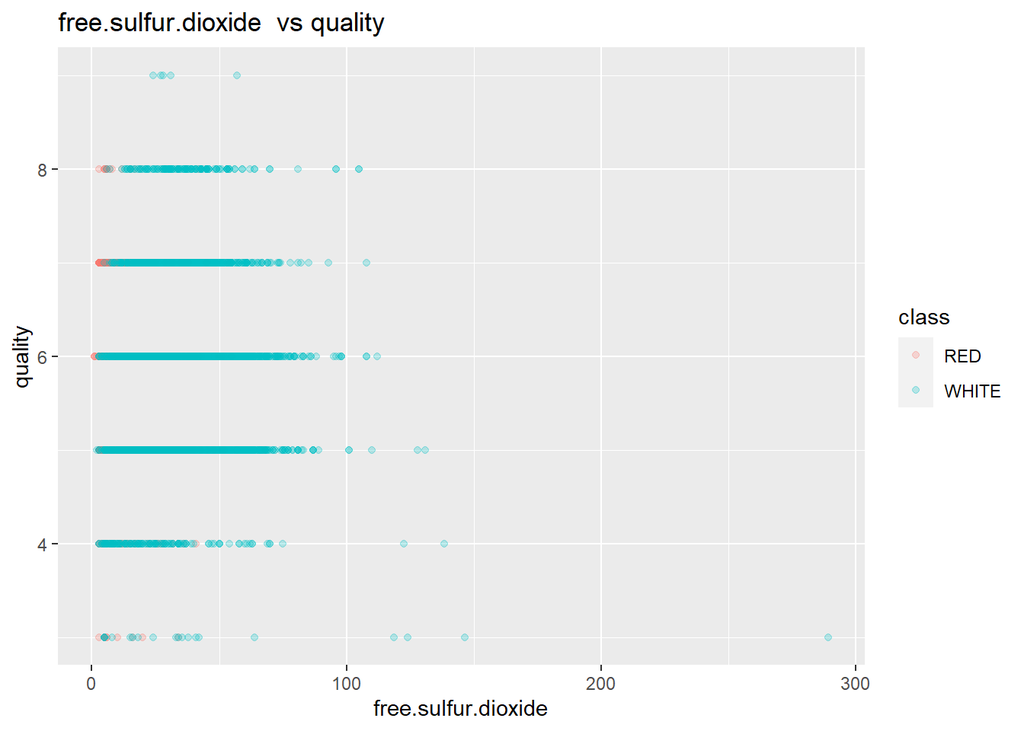

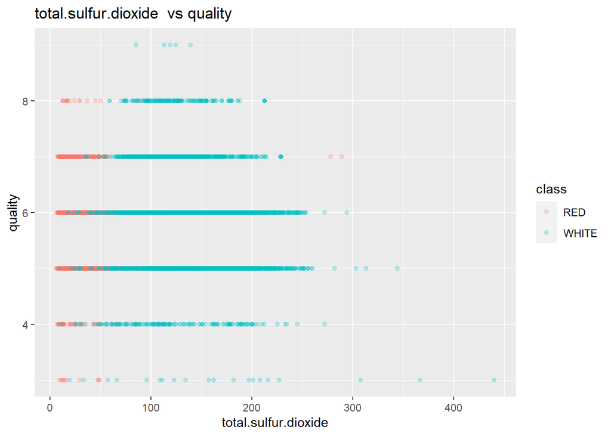

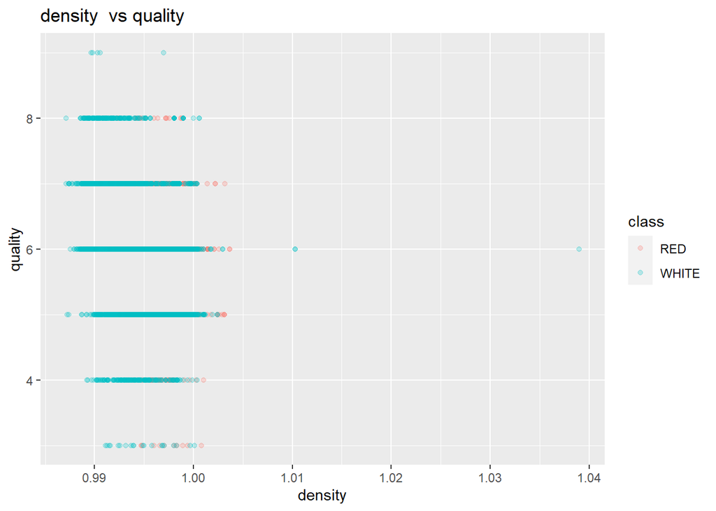

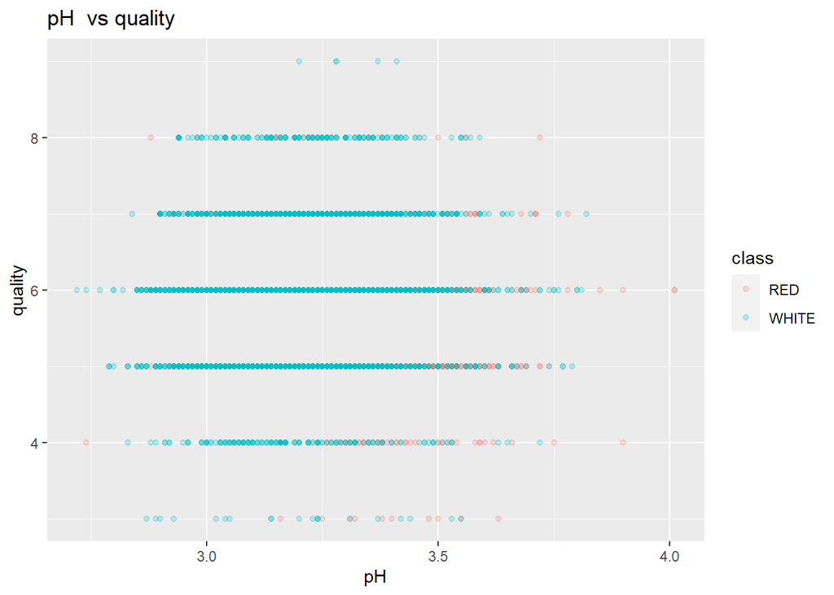

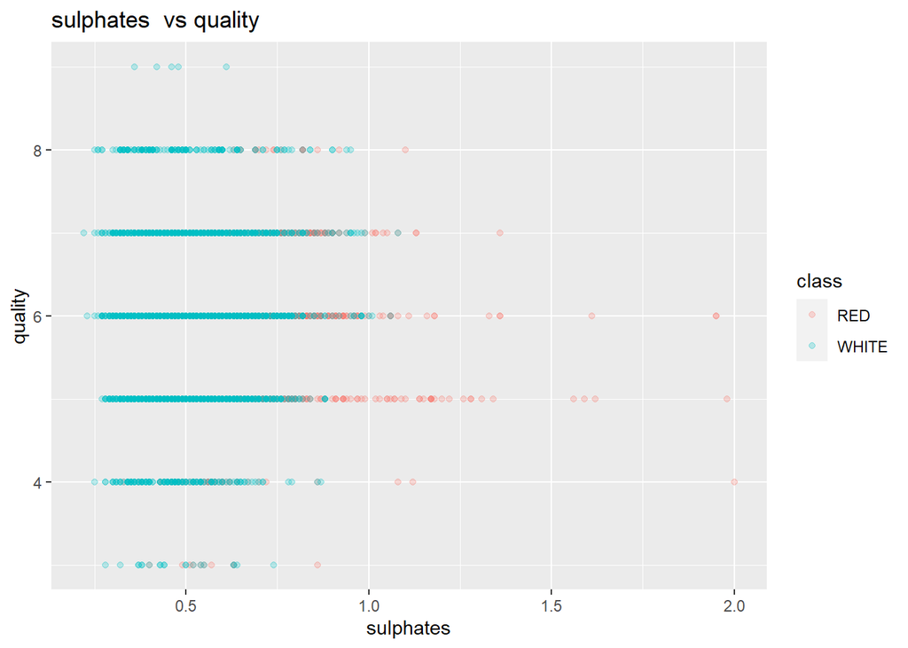

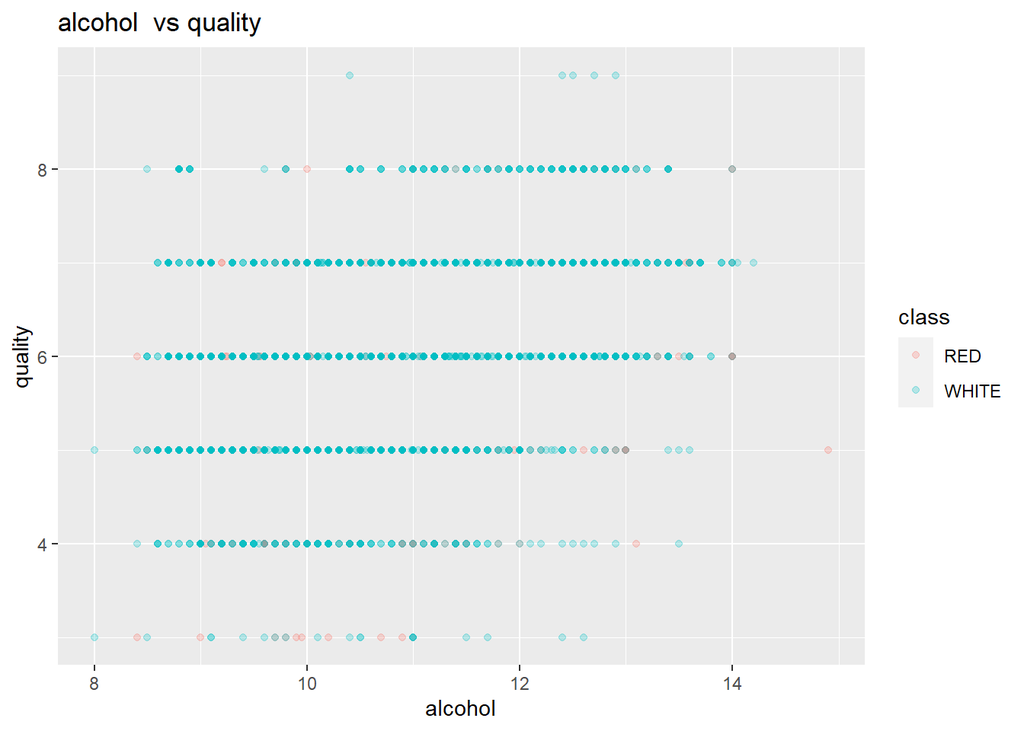

**Red Wines:** We are interested in understanding the behavior of quality over other variables considering just red wines.

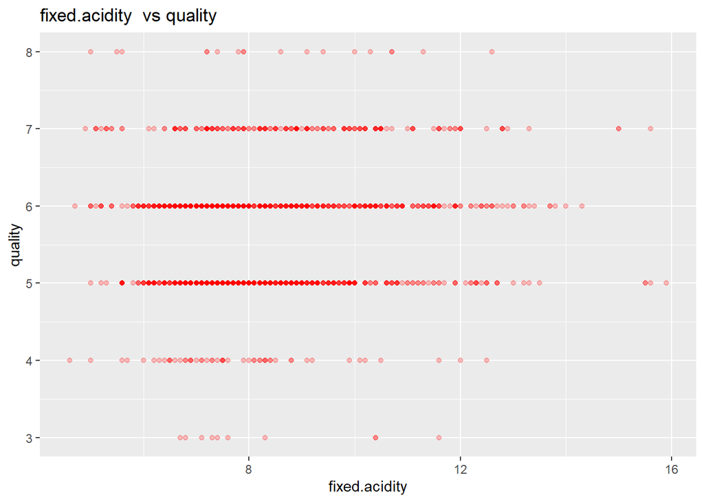